### ✅ **Put your name here**

#### ✅ Put your group member names here

# Day 10: In-Class Assignment

## Correlating yield with soil electrical conductivity ($EC_a$) with SciPy

[figure not shown]

The **learning goals** of the assignment are to:

- Use SciPy to compute Pearson and Spearman correlation coefficients between yield and soil electrical conductivity.
- Explore how these correlation coefficients can be sensitive to data you exclude or include.

> N.R. Kitchen, K.A. Sudduth, D.B. Myers, S.T. Drummond, S.Y. Hong (2005) Delineating productivity zones on claypan soil fields using apparent soil electrical conductivity. *Computers and Electronics in Agriculture* 46(1–3), pp. 285-308. DOI: 10.1016/j.compag.2004.11.012

## Part 1: Recap and Loading data with NumPy and plotting with Matplotlib

```python
# Although there are some exceptions, it is generally a good idea to keep all of your
# imports in one place so that you can easily manage them. Doing so also makes it easy
# to copy all of them at once and paste them into a new notebook you are starting.

# Bring in NumPy and Matplotlib, allowing for plots inside of the notebook.

import matplotlib.pyplot as plt
import numpy as np
import os
```

To compute correlations and basic linear models, we need the `stats` module from the [`scipy` package](https://docs.scipy.org/doc/scipy/reference/stats.html). This module contains a large number of probability distributions, summary and frequency statistics, correlation functions and statistical tests, masked statistics, kernel density estimation, quasi-Monte Carlo functionality, and more.

```python
from scipy import stats

# Hereafter, we CANNOT name a variable or function `stats`: that is the name we have assigned to the loaded module
```

To use this notebook for your in-class assignment, the file `field 2 yld 97_04 elev ec.csv` from the previous session must be in your `raw` folder. Let's load the data again like in the pre-class.

```python
filename = 'field 2 yld 97_04 elev ec.csv'
source = '..' + os.sep + 'raw' + os.sep
dest = '..' + os.sep + 'results' + os.sep

# Load data and have a few prints to make sure it is loading correctly

data = np.loadtxt(source+filename, delimiter=',', skiprows=1)
print('The dataset contains', data.shape[0], 'rows and', data.shape[1], 'columns.')
print(data[:3,:])
```

```
The dataset contains 1332 rows and 16 columns.
[[-9.21504721e+01  3.92337464e+01  5.73320000e+05  4.34306000e+06
   5.85461000e+03  1.78924000e+03  1.29400000e+03  8.03372000e+03
   2.58180000e+02  2.23211000e+03  1.35416000e+03  1.23014000e+03
   2.61100000e+02  7.69000000e+00  2.59400000e+01  3.46000000e+01]
 [-9.21503563e+01  3.92337455e+01  5.73330000e+05  4.34306000e+06
   5.13176000e+03  1.72417000e+03  1.24270000e+03  8.51537000e+03
   9.62300000e+01  8.45020000e+02  9.55060000e+02  1.95336000e+03
   2.61300000e+02  7.89000000e+00  2.80600000e+01  3.53300000e+01]
 [-9.21502404e+01  3.92337447e+01  5.73340000e+05  4.34306000e+06
   4.08248000e+03  1.58094000e+03  1.16177000e+03  8.20816000e+03
   3.28400000e+01  1.58332000e+03  8.13630000e+02  1.50626000e+03
   2.61480000e+02  7.72000000e+00  2.63600000e+01  3.66500000e+01]]
```

Just like in the pre-class, let's focus on the soybean yield and soil electrical conductivity data. Then we compute the mean yield data.

```python
# Double check with the Excel that we are getting the right columns
# Getting the yield data
moyield = data[:, 4:12]

# Soil electrical conductivity data
electric = data[:, -3:]

# Mean yield across 8 years
mean_yield = np.mean(moyield, axis=1)
```

**Remember:** Trusting statistical indices alone can be deceptive. You must always plot the data first, and then you perform statistics *if visually it makes sense to do so.*

[figure not shown]

Credits: [Anscombe (1973)](https://www.jstor.org/stable/2682899)

In our case, we plot the data to visually assess if there's any correlation at all. In this case, we will correlate yield with electrical conductivity like in the pre-class.

**Task 1:**

In your pre-class, you were tasked with add labels to the yield-vs-ECa plots and make them easier to read. Below is a possible way to make such plots.

Run the cell and read carefully each line.

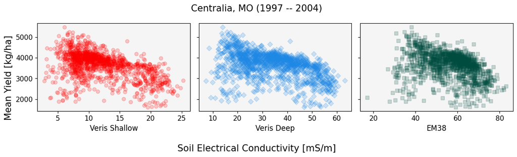

```python
fs = 15
xlabels = ['Veris Shallow', 'Veris Deep', 'EM38']
colors = ['#FF0000', '#1E88E5', '#004D40']
markers = ['o', 'D', 's']

fig, ax = plt.subplots(1,3, figsize=(12,3.5), sharex=False, sharey=True)
for i in range(len(ax)):
    ax[i].scatter(electric[:, i], mean_yield, alpha=0.2, c=colors[i], marker=markers[i]);
    ax[i].set_xlabel(xlabels[i], fontsize=0.8*fs)
    ax[i].tick_params(labelsize=0.75*fs)
    ax[i].set_facecolor('whitesmoke')

fig.supylabel('Mean Yield [kg/ha]', fontsize=fs)
fig.supxlabel('Soil Electrical Conductivity [mS/m]', fontsize=fs)
fig.suptitle('Centralia, MO (1997 -- 2004)', fontsize=fs)

fig.tight_layout()
```

Describe what you did the same in your pre-class task. What did you do different? What visualization aspects you had not considered before?

✎ *Your answer*

## Part 2: Computing correlation indices

As you read in the pre-class, one of the most common ways to measure correlation is through the [Pearson correlation coefficient](https://en.wikipedia.org/wiki/Pearson_correlation_coefficient). We can compute it in Python, with the [`pearsonr`](https://docs.scipy.org/doc/scipy/reference/generated/scipy.stats.pearsonr.html) function from the SciPy's `stats` module.

**Task 2:**

Run the following cell below and explain in your own words what the different numbers and results mean. *Your instructor should give you a quick rundown of the statistics at the start of the class. Raise your hand if this is not the case.*

```python
# Run this cell
# Correlation between average yield and VSh electrical conductivity

corr = stats.pearsonr(electric[:, 0], mean_yield)
conf = corr.confidence_interval(0.95)

print('The Pearson Correlation Index is', corr.statistic)
print('With a p-value of', corr.pvalue, '\n---')
print('With 95% of confidence, the true correlation value lies somewhere between\n',conf.low,'\tand\t', conf.high)
```

```
The Pearson Correlation Index is -0.48161314357835994
With a p-value of 2.7524260901571826e-78
---
With 95% of confidence, the true correlation value lies somewhere between
 -0.5218259782597193 	and	 -0.43926459672049584
```

**Task 3:**

Compute the correlation coefficients between average yield and the other two electrical conductivity measurements.

```python
# Your code
```

What can you conclude about the correlation between average yield and electrical conductivity? Are your conclusions supported by the plots?

✎ *Your answer*

**Task 4:**

Repeat Tasks 2 and 3 but with the Spearman coefficients using the `spearmanr` function from the SciPy's `stats` module.

```python
# Your code here
# Use stats.spearmanr instead of stats.pearsonr . Code-wise, is the only change
# Actual statistical values might be different, though
```

What can you conclude about the **Spearman** correlation between average yield and electrical conductivity? Are there any important deviations from the Pearson coefficients? Are your conclusions supported by the plots?

✎ *Your answer*

Here you can watch more information about the [Pearson coefficient](https://www.youtube.com/watch?v=k7IctLRiZmo) and the [Spearman coefficient](https://www.youtube.com/watch?v=XV_W1w4Nwoc).

## Part 3: Context matters: The whole pipeline is important

What happens if instead of averaging all eight growing seasons we only average five of them, the five soybean seasons?

**Task 5:**

- Compute the average **soybean** yield.
- Then make three subplots for soybean yield vs electrical conductivity.
- Finally, compute Pearson and Spearman correlation coefficients. (Do only Spearman if you're falling short on time)

```python
# Compute

soybean = data[:, [5,6,8,10,11]]
```

```
---
 pearsonr
Veris Shallow	-0.48161314357835994	2.7524260901571826e-78
Veris Deep	-0.4361794781649676	5.641204519593992e-63
EM38	-0.3360865239665024	1.5670852015929714e-36
---
 spearmanr
Veris Shallow	-0.4443801968140661	1.4330407312835485e-65
Veris Deep	-0.44403286121969804	1.8519202514218494e-65
EM38	-0.3833361678027977	7.139362154148347e-48
```

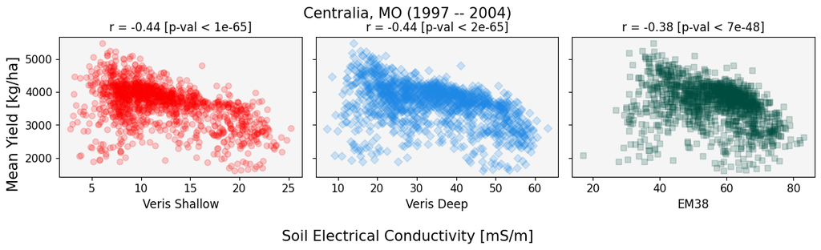

```python
### ANSWER ###

mean_yield = np.mean(moyield, axis=1)

fig, ax = plt.subplots(1,3, figsize=(12,3.5), sharex=False, sharey=True)
for i in range(len(ax)):
    ax[i].scatter(electric[:, i], mean_yield, alpha=0.2, c=colors[i], marker=markers[i]);
    ax[i].set_xlabel(xlabels[i], fontsize=0.8*fs)
    ax[i].tick_params(labelsize=0.75*fs)
    ax[i].set_facecolor('whitesmoke')

fig.supylabel('Mean Yield [kg/ha]', fontsize=fs)
fig.supxlabel('Soil Electrical Conductivity [mS/m]', fontsize=fs)
fig.suptitle('Centralia, MO (1997 -- 2004)', fontsize=fs)

fig.tight_layout()

for corrfunc in [stats.pearsonr, stats.spearmanr]:
    print('---\n',corrfunc.__name__)
    for i in range(electric.shape[1]):
        corr = corrfunc(electric[:,i], mean_yield)
        title = 'r = {:.2f} [p-val < {:.0e}]'.format(corr.statistic, corr.pvalue)
        ax[i].set_title(title)
        print(xlabels[i], corr.statistic, corr.pvalue, sep='\t')
```

What can you conclude about the correlation between average **soybean** yield and electrical conductivity? Are your conclusions supported by the plots? Are the conclusions what you expected?

✎ *Your answer*

**Task 6:**

Repeat Task 5 but now using only **corn yield**.

```python
# Your code
```

```
---
 pearsonr
Veris Shallow	-0.5616503063500359	1.3606710870263753e-111
Veris Deep	-0.5213080638094072	1.080685396067823e-93
EM38	-0.4423107555852043	6.57451182472214e-65
---
 spearmanr
Veris Shallow	-0.5131229272556204	2.393342912394013e-90
Veris Deep	-0.518412098867129	1.689461433014736e-92
EM38	-0.47437645866711975	1.0864731953491709e-75
```

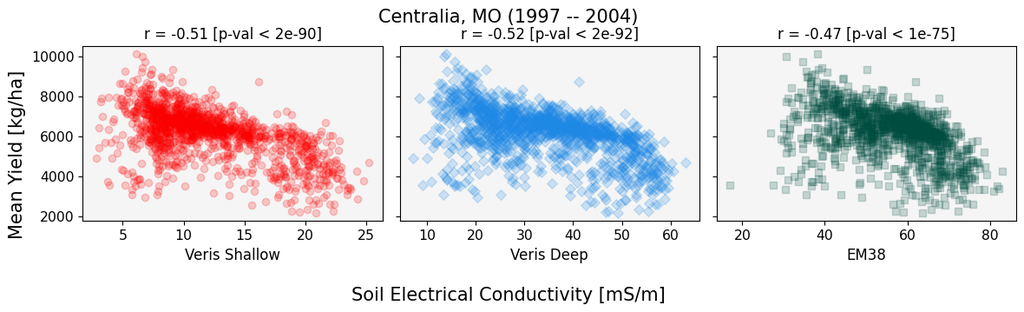

```python
### ANSWER ###

corn = data[:, [4,7,9]]
mean_yield = np.mean(corn, axis=1)

fig, ax = plt.subplots(1,3, figsize=(12,3.5), sharex=False, sharey=True)
for i in range(len(ax)):
    ax[i].scatter(electric[:, i], mean_yield, alpha=0.2, c=colors[i], marker=markers[i]);
    ax[i].set_xlabel(xlabels[i], fontsize=0.8*fs)
    ax[i].tick_params(labelsize=0.75*fs)
    ax[i].set_facecolor('whitesmoke')

fig.supylabel('Mean Yield [kg/ha]', fontsize=fs)
fig.supxlabel('Soil Electrical Conductivity [mS/m]', fontsize=fs)
fig.suptitle('Centralia, MO (1997 -- 2004)', fontsize=fs)

fig.tight_layout()

for corrfunc in [stats.pearsonr, stats.spearmanr]:
    print('---\n',corrfunc.__name__)
    for i in range(electric.shape[1]):
        corr = corrfunc(electric[:,i], mean_yield)
        title = 'r = {:.2f} [p-val < {:.0e}]'.format(corr.statistic, corr.pvalue)
        ax[i].set_title(title)
        print(xlabels[i], corr.statistic, corr.pvalue, sep='\t')
```

What can you conclude about the correlation between average **corn yield** yield and electrical conductivity? Are your conclusions supported by the plots? Are the conclusions what you expected? How do your conclusions compare to the soybean results from the prior task?

✎ *Your answer*

## Moral of the story: context matters

You probably observed that by just taking corn, now our correlation indices improved quite a bit. We went from 0.4 to 0.5. Ask yourself the following questions:

- Do our results imply that corn is more sensitive to soil electrical conductivity than soybean?
- Does it make sense to compare corn and soybean when we only have 3 years of corn data (as opposed to five from soybean)
- Both crops were not grown independently. They were rotating crops in the same field. Crop rotation is important and common. Does it make sense to separate the crops in the first place? Should we stick to the initial 8-year average?

✎ *Your answers*

The true answer here **does not depend on statistics**. The true answer depends on agronomy (or domain knowledge in general). Python and statistics will process whatever data we throw at them, but the results will be meaningless if the way we split the data is agronomically wrong. Maybe there is no causation and the whole correlation discussion is moot!

### Remember: correlation does not imply causation

[figure not shown]

### Fortunately in our case, there is evidence for causation

> Apparent profile soil electrical conductivity (ECa) provides an indirect measure of soil physical and chemical properties (McNeill, 1992, Rhoades et al., 1999), properties that can have a dominant influence on plant growth and yield (Jaynes et al., 1995, Lund et al., 2001, Zhang and Taylor, 2001, Kitchen et al., 2003). Characterization of soil variability can be improved by utilizing ECa measurements obtained from different types of ECa sensors (Sudduth et al., this issue). For claypan soils of the U.S. Midwest, ECa has been found to be highly correlated with topsoil thickness (i.e., depth to the Bt horizon) (Doolittle et al., 1994, Sudduth et al., 2001). This soil property causes variation in infiltration and water storage characteristics (Jamison et al., 1968) and is highly related to yield variation in crop growth years with average and below average precipitation (Kitchen et al., 1999). Previous analyses attempting to account for within-field yield variation were improved by including elevation with ECa measurements (Kitchen et al., 2003).

Taken from [Kitchen et al (2005)](https://doi.org/10.1016/j.compag.2004.11.012), the paper where this electrical conductivity and yield data set comes from.

The bottom line is: statistics and Python can only do so much. **True data science always has to be accompanied by domain knowledge.**

### Congratulations, you're done!

Submit this assignment by uploading it to the course Canvas web page. Go to the "Assignments" folder, find the appropriate submission folder link, and upload it there.

See you in class!

© Copyright 2025, Division of Plant Science & Technology—University of Missouri